# Predicting Activities

J.P. de la Cruz

23.11.2014

## Introduction

The goal is to use data collected from sensors attached to a person’s body in order to predict and evaluate the performed physical activity, which known as Human Activity Recognition.

In this concrete project, we employ the data provided and described in the [HAR project website](http://groupware.les.inf.puc-rio.br/har). Concretely the data for the Weight Lifting Exercises Dataset. Please refer to the website for a detailed description of the data beign collected, and the features built upon the data sensors.

## Preparing data

First, there are a number of features which we need to discard because they mostly consist of undefined measurements, concretely, over 95% of the samples are missing.

```r
library(plyr)
library(dplyr)
```

```r
library(ggplot2)
library(caret)
traindata <- tbl_df(read.csv("pml-training.csv"))
# discard non-informative features
# check out how many values are defined per variable
na.per.column <- sapply(names(traindata),function (colname) {
  # sum(is.na(traindata[,colname]))/nentries
  nentries <- nrow(traindata)
  regexp <- paste("^", colname, "$", sep="")
  traindata %>% select(matches(regexp)) %>% is.na %>% sum / nentries
})
# which features to work with
features <- names(na.per.column[na.per.column < 0.8])
```

Also, there are some features which are strongly correlated to the rest, or more importantly, they provide information about the source of the data (subject, timestamp at which it was collected) but provide no predicitve power.

It is specially important to discard the raw_timestamp feature, since it would wrongly make us believe that we can predict activity very well, since it is strongly correlated with the label (samples are collected sequentially: one subject after another, each performing one activity at a time).

```r
# also, there are some other columns which provide no predictive information
rem_col <- c("num_window","user_name","skewness","cvtd_timestamp","max_","min_","X",
             "total_","kurtosis","amplitude_","raw_timestamp")
regexp <- paste(c("(", paste(rem_col,collapse="|"), ")"), collapse = "")
traindata <- traindata[,features[grep(regexp,features, invert = TRUE)]]
```

## Method

We started by fitting a knn model to the data, in order to provide a baseline classifier to compare against. We employed 5-fold cross validation in order to look for a good value for the number of nearest neighbours. Data is scaled and centered.

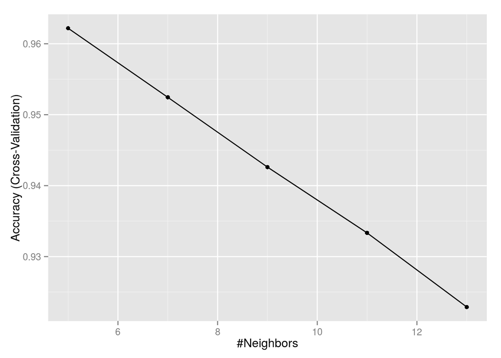

```r
if (!file.exists("knn_model.RData"))
{
  ctrl <- trainControl(method="cv", number = 5, allowParallel = TRUE)
  knnFit <- train(classe ~ ., preProcess = c("center","scale"), method = "knn",
                trControl = ctrl, data = traindata, tuneLength = 5)
  save(knnFit,file="knn_model.RData")
} else {
  load("knn_model.RData")
}

ggplot(knnFit)
```

Next we train a Gradient Boosting Model (GBM) on the data. GBM provide high accuracy and additional a ranking of the relevance of the different features.

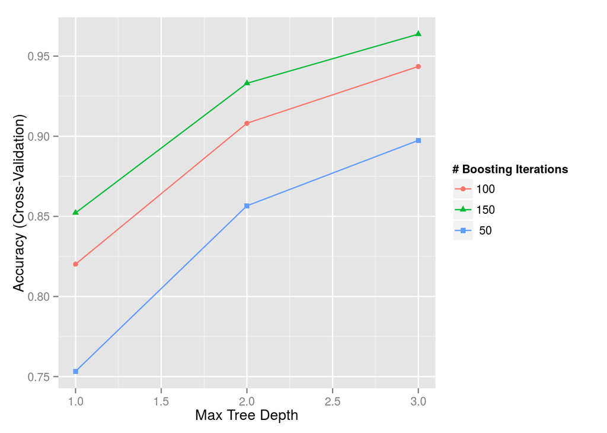

```r
if (!file.exists("gbm_model.RData"))
{
  set.seed(123)
  boostFit <- train(classe ~ ., method = "gbm", data = traindata, verbose = F,
                    trControl = trainControl(method = "cv", number = 10))
  save(boostFit,file="gbm_model.RData")
} else {
  load("gbm_model.RData")
}

ggplot(boostFit)
```

Finally, we can inspect what ranking of features the GBM returns,

```r
varImp(boostFit)
```

```
## gbm variable importance
##
##   only 20 most important variables shown (out of 49)
##
##                   Overall
## roll_belt         100.000
## pitch_forearm      50.289
## yaw_belt           38.980
## magnet_dumbbell_z  32.492
## magnet_dumbbell_y  23.249
## roll_forearm       22.578
## magnet_belt_z      17.787
## gyros_belt_z       14.186
## pitch_belt         12.822
## accel_forearm_x    12.691
## roll_dumbbell      11.725
## accel_dumbbell_y   10.405
## gyros_dumbbell_y    9.943
## accel_dumbbell_x    7.838
## magnet_dumbbell_x   7.684
## magnet_forearm_z    7.349
## yaw_arm             6.236
## accel_forearm_z     5.863
## roll_arm            5.517
## magnet_belt_y       5.117
```

It is interesting to see how pairs of related variables are among the most important, like roll_belt and yaw_belt, or y,z coordinates. They seems to provide a good parametrization of the movements as some plots suggest. As an example, consider the following plot,

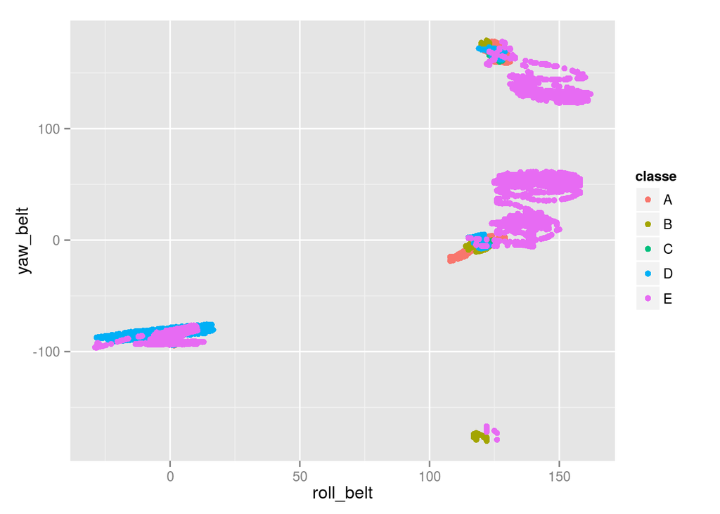

```r
qplot(roll_belt,yaw_belt,colour=classe,data=traindata)
```